# UNIDADE 3 - ALTURA DAS ÁRVORES

Relação Hipsométrica

Prof. Dr. Gabriel Agostini Orso

gabriel.orso@ufsm.br

Universidade Federal de Santa Maria

26 de agosto de 2026

## Aula de hoje

- UNIDADE 3 - ALTURA DAS ÁRVORES

  3.1 - Altura das árvores - semelhança de triângulos e resolução da tangente de ângulos

  3.2 - Relação hipsométrica e sua modelagem matemática

# Relação Hipsométrica

## Relação Hipsométrica

- A altura é uma medida mais difícil de ser obtida que o diâmetro
- À campo, é comum medir todos os diâmetros da parcela, porém apenas algumas das alturas, pois isso poupa tempo e dinheiro.

E o que se faz com as árvores cuja altura não foi medida?

Estimamos utilizando modelos matemáticos.

## Relação Hipsométrica

[interactive chart not shown]

## Relação Hipsométrica

[interactive chart not shown]

$$\begin{array}{l}
h = \textcolor{green}{\beta_0} + \textcolor{blue}{\beta_1} . \log(d) \\
h = \textcolor{green}{-13.626} + \textcolor{blue}{9.556} . \log(d)
\end{array}$$

## Relação Hipsométrica

- Essa relação permite avaliar perguntas como
  - Qual a altura da árvore de diâmetro médio $\bar{d}$?
  - Qual a altura da árvore de diâmetro quadrático médio $d_g$?

Supondo que $\bar{d} = 20.6 \enspace cm$ e $d_g = 22.8 \enspace cm$, quais são as alturas respectivas?

$$\begin{array}{l}
h = \textcolor{green}{-13.626} + \textcolor{blue}{9.556} . \log(\bar{d}) \\
h = \textcolor{green}{-13.626} + \textcolor{blue}{9.556} . \log(d_g)
\end{array}$$

$$\begin{array}{l}
f(\bar{d}) = 15.28 \enspace m \\
f(d_g) = 16.25 \enspace m
\end{array}$$

## Relação Hipsométrica

- Portanto essa relação matemática permite que a altura seja estimada a partir de um dado de diâmetro.
- A Engenharia Florestal está repleta de estudos e relações entre variáveis dendrométricas. E para quase todas essas, utilizam-se modelos de regressão para construir essas relações.

## Relação Hipsométrica

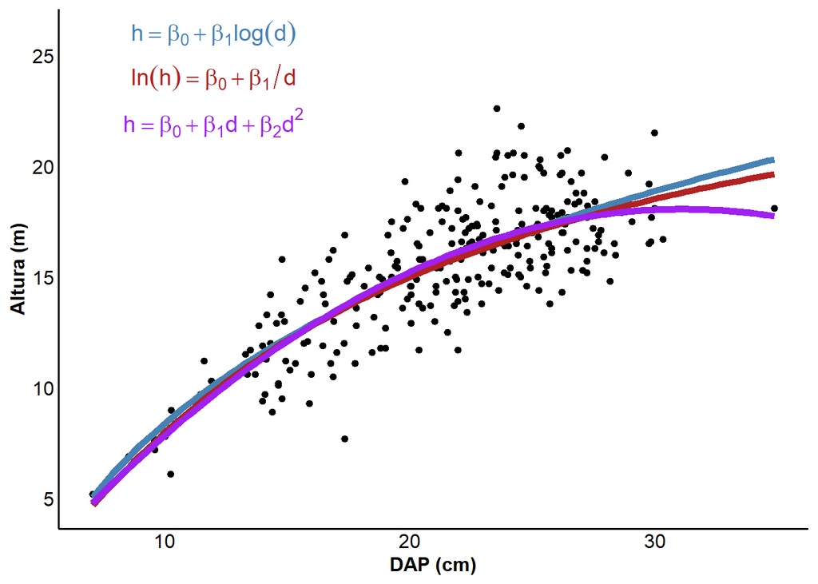

Existem diferentes modelos matemáticos testados na literatura para descrever essas relações.

## Relação Hipsométrica

$$h = \textcolor{red}{\beta_0} + \textcolor{red}{\beta_1}.d + \textcolor{red}{\beta_2}.d^2$$

Nos modelos de regressão, $\textcolor{red}{\beta_0}, \textcolor{red}{\beta_1}, \dots, \textcolor{red}{\beta_n}$ são os parâmetros do modelo.

**Parâmetros do Modelo**

Eles que regulam onde a curva irá passar nos dados.

## Relação Hipsométrica

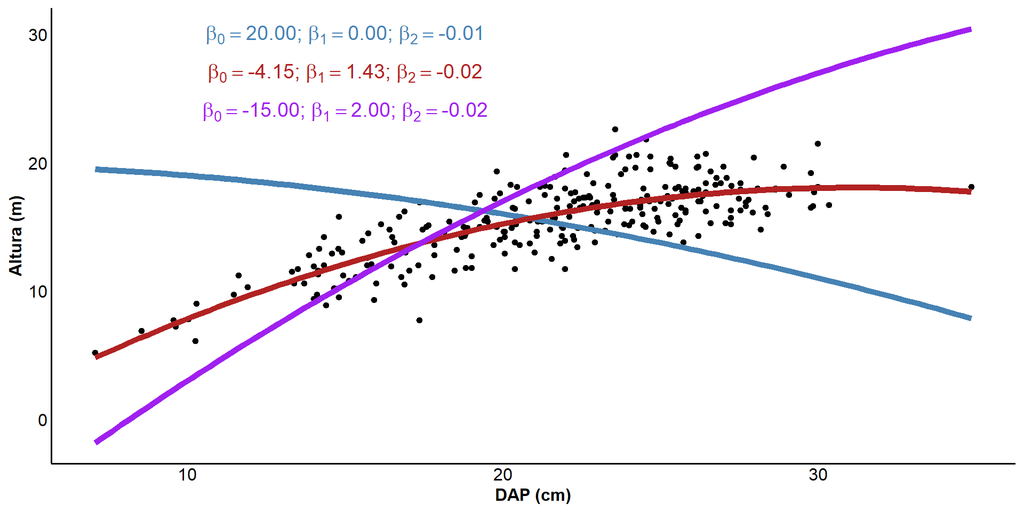

Como encontrar $\beta_i$ tal que a curva tenha o melhor ajuste?

## Relação Hipsométrica

### Mínimos Quadrados Ordinários - MQO

O Método dos Mínimos Quadrados Ordinários é o método utilizado para encontrar os valores de $\beta_i$ que melhor se ajustam à relação entre as variáveis.

**Condição de Utilização dos MQO**

O método dos MQO só funcionam para modelos lineares!

Modelos lineares são aqueles cujos parâmetros estão na forma aditiva entre si e com expoente 1:

$$\begin{array}{l}
\textcolor{green}{y = \beta_0 + \beta_1.X_1 + \beta_2.X_2} \\
\textcolor{red}{y = \beta_0.\beta_1^{X_1}.X_2} \\
\textcolor{red}{y = \beta_0.X_1^{\beta_1}.X_2^{\beta_2}} \\
\textcolor{green}{y = \beta_0 + \beta_1.X_1.X_2 + \beta_2.X_3} \\
\end{array}$$

## Mínimos Quadrados Ordinários

[interactive chart not shown]

Seja o modelo

$$\begin{array}{l}
h = \beta_0 + \beta_1.d \\
Y = \beta_0 + \beta_1.X
\end{array}$$

Aqui, $h$ é a variável $Y$, chamada de variável dependente ou variável resposta. Já a variável $d$ será a variável $X$, chamada de variável independente ou covariável.

## Mínimos Quadrados Ordinários

[interactive chart not shown]

Pelos MQO, os parâmetros $\beta_i$ são estimados via:

$$\hat{\beta}_1 = {\sum XY - {\left(\sum X\right)\left(\sum Y\right) \over n} \over \sum X^2 - {\left(\sum X \right)^2 \over n}}$$

$$\hat{\beta}_0 = \bar{Y} - \hat{\beta}_1.\bar{X}$$

## Mínimos Quadrados Ordinários

| N | X (d) | Y (h) | Y² | X² | XY |
| --- | --- | --- | --- | --- | --- |
| 1 | 19.0 | 12.7 | 161.3 | 361.1 | 241.3 |
| 2 | 26.9 | 18.4 | 338.6 | 723.5 | 494.9 |
| 3 | 24.8 | 17.1 | 292.4 | 616.4 | 424.6 |
| 4 | 27.2 | 16.3 | 265.7 | 740.7 | 443.6 |
| 5 | 14.1 | 11.6 | 134.6 | 199.7 | 163.9 |
| 6 | 16.5 | 11.9 | 141.6 | 270.8 | 195.8 |
| 7 | 17.6 | 15.1 | 228.0 | 311.0 | 266.3 |
| 8 | 20.0 | 14.6 | 213.2 | 400.9 | 292.3 |
| 9 | 20.1 | 14.2 | 201.6 | 402.1 | 284.8 |
| 10 | 23.9 | 16.4 | 269.0 | 569.9 | 391.5 |
| 11 | 13.5 | 11.7 | 136.9 | 182.2 | 157.9 |
| 12 | 13.3 | 11.5 | 132.2 | 177.0 | 153.0 |
| 13 | 16.9 | 10.5 | 110.2 | 284.6 | 177.1 |
| 14 | 23.9 | 16.8 | 282.2 | 569.9 | 401.1 |
| 15 | 25.7 | 17.8 | 316.8 | 659.9 | 457.2 |

## Mínimos Quadrados Ordinários

| N | X (d) | Y (h) | Y² | X² | XY |
| --- | --- | --- | --- | --- | --- |
| 1 | 19.0 | 12.7 | 161.3 | 361.1 | 241.3 |
| 2 | 26.9 | 18.4 | 338.6 | 723.5 | 494.9 |
| 3 | 24.8 | 17.1 | 292.4 | 616.4 | 424.6 |
| 4 | 27.2 | 16.3 | 265.7 | 740.7 | 443.6 |
| 5 | 14.1 | 11.6 | 134.6 | 199.7 | 163.9 |
| 6 | 16.5 | 11.9 | 141.6 | 270.8 | 195.8 |
| 7 | 17.6 | 15.1 | 228.0 | 311.0 | 266.3 |
| 8 | 20.0 | 14.6 | 213.2 | 400.9 | 292.3 |
| 9 | 20.1 | 14.2 | 201.6 | 402.1 | 284.8 |
| 10 | 23.9 | 16.4 | 269.0 | 569.9 | 391.5 |
| 11 | 13.5 | 11.7 | 136.9 | 182.2 | 157.9 |
| 12 | 13.3 | 11.5 | 132.2 | 177.0 | 153.0 |
| 13 | 16.9 | 10.5 | 110.2 | 284.6 | 177.1 |
| 14 | 23.9 | 16.8 | 282.2 | 569.9 | 401.1 |
| 15 | 25.7 | 17.8 | 316.8 | 659.9 | 457.2 |

$$\begin{array}{l}
\textcolor{red}{\sum X = \displaystyle\sum_{i=1}^{15} x_i = 303.35} \\
\textcolor{blue}{\sum Y = \displaystyle\sum_{i=1}^{15} y_i = 216.6} \\
\textcolor{green}{\sum Y^2 = \displaystyle\sum_{i=1}^{15} y^2_i = 3224.36} \\
\textcolor{purple}{\sum X^2 = \displaystyle\sum_{i=1}^{15} x^2_i = 6469.75} \\
\textcolor{orange}{\sum XY = \displaystyle\sum_{i=1}^{15} x_iy_i = 4545.44}
\end{array}$$

## Mínimos Quadrados Ordinários

| N | X (d) | Y (h) | Y² | X² | XY |
| --- | --- | --- | --- | --- | --- |
| 1 | 19.0 | 12.7 | 161.3 | 361.1 | 241.3 |
| 2 | 26.9 | 18.4 | 338.6 | 723.5 | 494.9 |
| 3 | 24.8 | 17.1 | 292.4 | 616.4 | 424.6 |
| 4 | 27.2 | 16.3 | 265.7 | 740.7 | 443.6 |
| 5 | 14.1 | 11.6 | 134.6 | 199.7 | 163.9 |
| 6 | 16.5 | 11.9 | 141.6 | 270.8 | 195.8 |
| 7 | 17.6 | 15.1 | 228.0 | 311.0 | 266.3 |
| 8 | 20.0 | 14.6 | 213.2 | 400.9 | 292.3 |
| 9 | 20.1 | 14.2 | 201.6 | 402.1 | 284.8 |
| 10 | 23.9 | 16.4 | 269.0 | 569.9 | 391.5 |
| 11 | 13.5 | 11.7 | 136.9 | 182.2 | 157.9 |
| 12 | 13.3 | 11.5 | 132.2 | 177.0 | 153.0 |
| 13 | 16.9 | 10.5 | 110.2 | 284.6 | 177.1 |
| 14 | 23.9 | 16.8 | 282.2 | 569.9 | 401.1 |
| 15 | 25.7 | 17.8 | 316.8 | 659.9 | 457.2 |

$$\hat{\beta}_1 = {\textcolor{orange}{\sum XY} - {\left(\textcolor{red}{\sum X}\right)\left(\textcolor{blue}{\sum Y}\right) \over n} \over \textcolor{purple}{\sum X^2} - {\left(\textcolor{red}{\sum X} \right)^2 \over n}}$$

$$\hat{\beta}_1 = {4545.44 - {\left(303.35 \right) \left(216.6 \right) \over 15} \over 6469.75 - {\left( 303.35\right)^2 \over 15}} = 0.4927$$

$$\hat{\beta}_0 = \bar{Y} - \left(\hat{\beta}_1 . \bar{X} \right)$$

$$\hat{\beta}_0 = 14.44 - \left(0.4927\times 20.22\right) = 4.4753$$

## Mínimos Quadrados Ordinários

Portanto a regressão ajustada fica:

$$Y = \hat{\beta}_0 + \hat{\beta}_1 . X$$

$$h = 4.4753 + 0.4927 \times d$$

Qual a altura de uma árvore com **17.2** cm de diâmetro?

$h = 12.94974 \enspace m$

## Mínimos Quadrados Ordinários

| N | d | h | Y | X |
| --- | --- | --- | --- | --- |
| 1 | 19.0 | 12.7 |  |  |
| 2 | 26.9 | 18.4 |  |  |
| 3 | 24.8 | 17.1 |  |  |
| 4 | 27.2 | 16.3 |  |  |
| 5 | 14.1 | 11.6 |  |  |
| 6 | 16.5 | 11.9 |  |  |
| 7 | 17.6 | 15.1 |  |  |
| 8 | 20.0 | 14.6 |  |  |

Exercício: Encontre os parâmetros ajustados do modelo

$$\log(h) = \beta_0 + \beta_1. \left({1 \over d} \right)$$

## Mínimos Quadrados Ordinários

| N | d | h | Y | X |
| --- | --- | --- | --- | --- |
| 1 | 19.0 | 12.7 | 2.5416 | 0.0526 |
| 2 | 26.9 | 18.4 | 2.9124 | 0.0372 |
| 3 | 24.8 | 17.1 | 2.8391 | 0.0403 |
| 4 | 27.2 | 16.3 | 2.7912 | 0.0367 |
| 5 | 14.1 | 11.6 | 2.4510 | 0.0708 |
| 6 | 16.5 | 11.9 | 2.4765 | 0.0608 |
| 7 | 17.6 | 15.1 | 2.7147 | 0.0567 |
| 8 | 20.0 | 14.6 | 2.6810 | 0.0499 |

Exercício: Encontre os parâmetros ajustados do modelo

$$\log(h) = \beta_0 + \beta_1. \left({1 \over d} \right)$$

$$\begin{array}{l}
\sum X = 0.405 \\
\sum Y = 21.40746
\end{array}$$

$$\begin{array}{l}
\sum X^2 = 0.0215331\\
\sum Y^2 = 57.4906087\\
\sum XY = 1.0706938
\end{array}$$

$$\begin{array}{l}
\hat{\beta}_0 = 3.3174 \\
\hat{\beta}_1 = -12.6711
\end{array}$$

## Qualidade do Ajuste

- Podemos pensar na análise de regressão como quanto da variabilidade de $Y$ é explicada por $X$.
- Existem maneiras de avaliar quão bem $X$ consegue explicar $Y$. Tais medidas fazem uso das Somas de Quadrados, que são medidas de variabilidade.

**Somas de Quadrados**

Na Regressão Linear existem três Somas de Quadrados:

- Soma de Quadrados Total: $SQT = \sum Y^2 - {\left(\sum Y \right)^2 \over n}$
- Soma de Quadrados da Regressão: $SQR = \hat{\beta_1}\left(\sum XY - {\left(\sum X \right)\left(\sum Y \right) \over n}\right)$
- Soma de Quadrados do Erro/Resíduo: $SQE = SQT - SQReg$

## Qualidade do Ajuste

### Tabela de Análise de Variância (ANOVA) da Regressão

| Fonte de Variação | Graus de Liberdade ($gl$) | Soma dos Quadrados ($SQ$) | Quadrados Médios ($QM$) | Estatística $F$ | Valor-$p$ |
| --- | --- | --- | --- | --- | --- |
| **Regressão (Modelo)** | $p-1$ | $SQR$ | $QMR = \frac{SQR}{p-1}$ | $F = \frac{QMR}{QME}$ | $P(F > f_{calc})$ |
| **Resíduo (Erro)** | $n - p$ | $SQE$ | $QME = \frac{SQE}{n - p}$ | — | — |
| **Total** | $n - 1$ | $SQT$ | — | — | — |

Onde $p$ = número de parâmetros do modelo ($\beta_i$); $n$ = número de observações.

Veja que a soma de quadrados totais (SQT) SEMPRE será a soma de $SQR + SQE$, isto é: $SQT = SQR + SQE$

## Qualidade do Ajuste

### Tabela de Análise de Variância (ANOVA) da Regressão

Ao realizar uma ANOVA, testamos as seguintes hipóteses:

- $H_0$: O modelo ajustado não representa a relação entre $Y$ e $X(s)$.
- $H_1$: O modelo ajustado representa a relação entre $Y$ e $X(s)$.

## Qualidade do Ajuste

### Coeficiente de Determinação ($R^2$)

Outra medida é o Coeficiente de Determinação - $R^2$, calculado como

$$R^2 = {\text{Soma de Quadrados da Regressão} \over \text{Soma de Quadrados Total}} = {SQR \over SQT}$$

**$R^2$**

Essa medida é adimensional, e varia entre 0 e 1. Quanto mais próximo de 1, melhor.

## Qualidade do Ajuste

### Coeficiente de Determinação ($R^2$)

Dada a relação $SQT = SQR + SQE$, o coeficiente de determinação $R^2$ também pode ser escrito como

$$R^2 = 1 - {SQE \over SQT}$$

## Qualidade do Ajuste

### Erro Padrão de Estimativa - ($S_{yx}$)

É um indicador do erro cometido quando se utiliza a equação ajustada para se obter uma estimativa.

$$S_{yx} = \sqrt{{SQE \over {n-p}}} = \sqrt{QME}$$

**$S_{yx}$**

O Erro Padrão de Estimativa ($S_{yx}$) tem a mesma unidade da variável $Y$. Ele é basicamente um desvio-padrão, portanto é sempre positivo.

## Qualidade do Ajuste

### Erro Padrão de Estimativa - ($S_{yx}$)

O $S_{yx}$ também pode ser representado em porcentagem (%)

$$S_{yx}\% = {S_{yx} \over \bar{Y}} . 100$$

**$S_{yx}\%$**

Nesse caso ele não terá unidade, e interpreta-se algo como “O modelo erra em média $S_{yx}\%$ por cento”.

## Qualidade do Ajuste

### Exemplo

Seja o seguinte modelo linear simples, com $n = 30$ observações

$$\hat{Y} = 2,625704 - 0,591614.X$$

## Qualidade do Ajuste

### Exemplo

| Fonte de Variação | Graus de Liberdade ($gl$) | Soma dos Quadrados ($SQ$) | Quadrados Médios ($QM$) |
| --- | --- | --- | --- |
| **Regressão (Modelo)** | $1$ | $3,44601$ | $3,44601$ |
| **Resíduo (Erro)** | $28$ | $3,24351$ | $0,11584$ |
| **Total** | $29$ | $6,68952$ |  |

## Qualidade do Ajuste

### Exemplo

Teste F

$$F = {QMR \over QME} = {3,44601 \over 0,11584} = 29,75^{**}$$

Rejeita $H_0$, o modelo ajustado representa a relação entre $X$ e $Y$ ao nível de 1% de significância.

## Qualidade do Ajuste

### Exemplo

Erro Padrão de Estimativa $S_{yx}$

$$S_{yx} = \sqrt{QME} = \sqrt{0,1157} = 0,3404$$

$$S_{yx}\% = {S_{yx} \over \bar{Y}}.100 = {0,3404 \over \left({20,58 \over 30} \right)} . 100 = 49,62\%$$

# Exercício

## Exercício

| N | d (cm) | h (m) |
| --- | --- | --- |
| 1 | 10 | 11.0 |
| 2 | 13 | 15.0 |
| 3 | 15 | 17.0 |
| 4 | 20 | 19.0 |
| 5 | 21 | 21.0 |
| 6 | 25 | 23.0 |
| 7 | 28 | 27.0 |
| 8 | 22 | 21.0 |
| 9 | 19 | 21.0 |
| 10 | 9 | 9.0 |
| 11 | 16 | 18.0 |
| 12 | 13 | 15.0 |
| 13 | 25 | 23.0 |
| 14 | 9 | 10.0 |
| 15 | 15 | 14.5 |

[interactive chart not shown]

Que tipo de curva melhor representa esses dados?. Uma reta? Uma parábola?

$Y = \beta_0 + \beta_1.X$

# Médias dendrométricas

## Médias dendrométricas

Assim como para diâmetro, algumas alturas médias ou estimadas são particularmente importantes para a ciência florestal.

**Exemplos de alturas oportunas**

- Altura média $\bar{h}$
- Alturade Lorey $h_L$
- Alturas Representativas
- Alturas dominantes

## Altura média $\bar{h}$

A Altura média $\bar{h}$ é obtida a partir da média das alturas observadas.

Para dados não agrupados

$$\bar{h} = { \displaystyle\sum_{i=1}^{n} h_i \over n }$$

Para dados agrupados

$$\bar{h} = { \displaystyle\sum_{j=1}^{k} h_j f_j \over \displaystyle\sum_{j=1}^{k} f_j}$$

## Altura de Lorey $h_L$

A Altura de Lorey é calculada como uma altura média ponderada pela área transversal.

Para dados não agrupados

$$h_L = {\displaystyle\sum_{i=1}^{n} g_i h_i \over \displaystyle\sum_{i=1}^{n} g_i}$$

Para dados agrupados

$$h_L = { \displaystyle\sum_{j=1}^{k} g_j h_j f_j \over \displaystyle\sum_{j=1}^{k} g_j f_j}$$

## Alturas Representativas

São aquelas obtidas utilizando uma equação ajustada. Por exemplo:

- Altura de área transversal média ($h_g$): Corresponde à altura estimada utilizando $d_g$ na equação.

$$h = 2,87 + 5,22 . d$$

Então,
$$h_g = 2,87 + 5,22 . d_g$$

## Alturas Representativas

Exemplo:

Altura da árvore de área transversal central $h_z$ supondo certo modelo hipsométrico

$$\ln(h_z) = \beta_0 + \beta_1.{1 \over d_z}$$

$$h_z = e^{\beta_0 + \beta_1{1 \over d_z}}$$

## Altura Dominante

- A altura dominante é uma altura considerada como a altura das maiores árvores do povoamento.
- Existem diversas definições do que pode ser uma altura dominante.

## Altura Dominante

1. H média das 100 árvores mais altas por hectare (Hart);
2. H média de 20% das árvores mais altas por hectare;
3. H média das 100 árvores mais grossas por hectare (Assmann) $h_{dom}$, $h_{100}$;
4. H média de 20% das árvores mais grossas por hectare;
5. H correspondente à árvore com o DAP igual à média aritmética do DAP do povoamento mais 3 desvio padrão (Naslund);
6. H correspondente ao DAP médio de 20% das árvores mais grossas no povoamento (Weise);
7. H média das dominantes e codominantes (Meyer).

## Altura Dominante

1. H média das 100 árvores mais altas por hectare (Hart);
2. H média de 20% das árvores mais altas por hectare;

c) H média das 100 árvores mais grossas por hectare (Assmann) $h_{dom}$, $h_{100}$;

4. H média de 20% das árvores mais grossas por hectare;
5. H correspondente à árvore com o DAP igual à média aritmética do DAP do povoamento mais 3 desvio padrão (Naslund);
6. H correspondente ao DAP médio de 20% das árvores mais grossas no povoamento (Weise);
7. H média das dominantes e codominantes (Meyer).

## Altura Dominante

### Altura de Assmann

Considera-se como altura dominante a altura média das 100 árvores de maior área transversal no hectare.

**Proporcional ao hectare**

Caso tenha-se uma parcela, por exemplo, com 30x30m, utilizam-se as X maiores árvores da parcela.

A área da parcela vale $30\times 30 \enspace m = 900 \enspace m^2 = 0,09 ha$, portanto utilizam-se $100 \times 0,09 = 9$ árvores.

## Altura Dominante

### Exemplo

| N | d (cm) | h (m) |
| --- | --- | --- |
| 1 | 10 | 11.0 |
| 2 | 13 | 15.0 |
| 3 | 15 | 17.0 |
| 4 | 20 | 19.0 |
| 5 | 21 | 21.0 |
| 6 | 25 | 23.0 |
| 7 | 28 | 27.0 |
| 8 | 22 | 21.0 |
| 9 | 19 | 21.0 |
| 10 | 9 | 9.0 |
| 11 | 16 | 18.0 |
| 12 | 13 | 15.0 |
| 13 | 25 | 23.0 |
| 14 | 9 | 10.0 |
| 15 | 15 | 14.5 |

Seja o banco de dados obtido de uma parcela de $20 \times 25$ m. Qual é a altura dominante?

Área da parcela $a = 20 \enspace m \times 25 \enspace m = 500 \enspace m^2 = 0,05 \enspace ha$, portanto serão $100 \times 0,05 = 5$ árvores.

## Altura Dominante

### Exemplo

| N | d (cm) | h (m) |
| --- | --- | --- |
| 1 | 10 | 11.0 |
| 2 | 13 | 15.0 |
| 3 | 15 | 17.0 |
| 4 | 20 | 19.0 |
| 5 | 21 | 21.0 |
| 6 | 25 | 23.0 |
| 7 | 28 | 27.0 |
| 8 | 22 | 21.0 |
| 9 | 19 | 21.0 |
| 10 | 9 | 9.0 |
| 11 | 16 | 18.0 |
| 12 | 13 | 15.0 |
| 13 | 25 | 23.0 |
| 14 | 9 | 10.0 |
| 15 | 15 | 14.5 |

Seja o banco de dados obtido de uma parcela de $20 \times 25$ m. Qual é a altura dominante?

Área da parcela $a = 20 \enspace m \times 25 \enspace m = 500 \enspace m^2 = 0,05 \enspace ha$, portanto serão $100 \times 0,05 = 5$ árvores.

## Altura Dominante

### Exercício

| n | d (cm) | h (m) | n | d (cm) | h (m) | n | d (cm) | h (m) | n | d (cm) | h (m) |
| --- | --- | --- | --- | --- | --- | --- | --- | --- | --- | --- | --- |
| 1 | 11.5 | 20.0 | 6 | 24.0 | 40.4 | 11 | 21.3 | 36.0 | 16 | 24.4 | 41.1 |
| 2 | 13.3 | 22.9 | 7 | 17.1 | 29.1 | 12 | 16.5 | 28.2 | 17 | 17.3 | 29.5 |
| 3 | 23.1 | 39.0 | 8 | 7.5 | 13.6 | 13 | 16.7 | 28.6 | 18 | 3.7 | 7.3 |
| 4 | 14.9 | 25.6 | 9 | 10.7 | 18.8 | 14 | 15.2 | 26.0 | 19 | 18.4 | 31.3 |
| 5 | 15.3 | 26.2 | 10 | 12.1 | 21.0 | 15 | 11.5 | 20.0 | 20 | 11.9 | 20.7 |

Calcule a altura dominante da parcela abaixo, sabendo que a área da parcela é de $30 \enspace m \times 40 \enspace m$.

$$h_{dom} = 31.8 \enspace m \qquad h = 26.3 \enspace m$$

## Altura Dominante

**Importância no Manejo Florestal**

- A Altura Dominante é uma medida muito importante no manejo florestal.
- É a variável mais utilizada para indicar a capacidade produtiva de um determinado local.